# Datathon 2022

Sky, Sunny, Sameer

2022-05-31

## Power Play Specialists

### Successful Shots (Goals)

```r
library(dplyr)
NWHL <- read.csv("/Users/Sameer/Desktop/Rotman MMA Summer Datathon NWHL.csv",header = TRUE)
```

```r
#### Power Play Specialists
# find goals in every game
Goal_January23 <- filter(NWHL, Event == "Goal", game_date == "23-01-2021")

Goal_January24 <- filter(NWHL, Event == "Goal", game_date == "24-01-2021")

Goal_January26 <- filter(NWHL, Event == "Goal", game_date == "26-01-2021")

Goal_January27 <- filter(NWHL, Event == "Goal", game_date == "27-01-2021")

Goal_January30 <- filter(NWHL, Event == "Goal", game_date == "30-01-2021")

Goal_January31 <- filter(NWHL, Event == "Goal", game_date == "31-01-2021")

Goal_February01 <- filter(NWHL, Event == "Goal", game_date == "01-02-2021")
```

```r
# find players and the number of their goals in every game
Jan23 = Goal_January23 %>% group_by(Player) %>%
                    summarise(total_goal_Jan23 = length(Event))

Jan24 = Goal_January24 %>% group_by(Player) %>%
                    summarise(total_goal_Jan24 = length(Event))

Jan26 = Goal_January26 %>% group_by(Player) %>%
                    summarise(total_goal_Jan26 = length(Event))

Jan27 = Goal_January27 %>% group_by(Player) %>%
                    summarise(total_goal_Jan27 = length(Event))

Jan30 = Goal_January30 %>% group_by(Player) %>%
                    summarise(total_goal_Jan30 = length(Event))

Jan31 = Goal_January31 %>% group_by(Player) %>%
                    summarise(total_goal_Jan31 = length(Event))

Feb01 = Goal_February01 %>% group_by(Player) %>%
                    summarise(total_goal_Feb01 = length(Event))
```

```r
# merge the Goal data
Player_goal_merge1 <- merge(Jan23, Jan24, by="Player", all = TRUE)

Player_goal_merge2 <- merge(Player_goal_merge1, Jan26, by="Player", all = TRUE)

Player_goal_merge3 <- merge(Player_goal_merge2, Jan27, by="Player", all=TRUE)

Player_goal_merge4 <- merge(Player_goal_merge3, Jan30, by="Player", all=TRUE)

Player_goal_merge5 <- merge(Player_goal_merge4, Jan31, by="Player", all=TRUE)

Player_goal_merge_final <- merge(Player_goal_merge5, Feb01, by="Player", all=TRUE)

Player_goal_merge_final
```

```
##                     Player total_goal_Jan23 total_goal_Jan24 total_goal_Jan26
## 1        Alyssa Wohlfeiler               NA               NA               NA
## 2            Amanda Conway               NA                1               NA
## 3               Amy Curlew               NA               NA               NA
## 4           Audra Richards               NA                1               NA
## 5        Autumn MacDougall               NA               NA               NA
## 6   Breanne Wilson-Bennett               NA                2               NA
## 7           Brooke Boquist               NA               NA                1
## 8         Cailey Hutchison               NA                1               NA
## 9        Christina Putigna                1               NA                1
## 10             Emily Fluke               NA               NA               NA
## 11            Emily Janiga                1               NA               NA
## 12             Emma Vlasic               NA               NA               NA
## 13              Haley Mack               NA                1                1
## 14           Haylea Schmid               NA                1               NA
```

[output cut: 79 more lines]

```r
# calculate the total number of goals for each player
goal_sum = rowSums(Player_goal_merge_final[2:8], na.rm = TRUE)
Total_game <- 7
Games_played <- Total_game - rowSums(is.na(Player_goal_merge_final))
Player_goal_list <- cbind(Player_goal_merge_final, goal_sum, Games_played)
Player_goal_list
```

```
##                     Player total_goal_Jan23 total_goal_Jan24 total_goal_Jan26
## 1        Alyssa Wohlfeiler               NA               NA               NA
## 2            Amanda Conway               NA                1               NA
## 3               Amy Curlew               NA               NA               NA
## 4           Audra Richards               NA                1               NA
## 5        Autumn MacDougall               NA               NA               NA
## 6   Breanne Wilson-Bennett               NA                2               NA
## 7           Brooke Boquist               NA               NA                1
## 8         Cailey Hutchison               NA                1               NA
## 9        Christina Putigna                1               NA                1
## 10             Emily Fluke               NA               NA               NA
## 11            Emily Janiga                1               NA               NA
## 12             Emma Vlasic               NA               NA               NA
## 13              Haley Mack               NA                1                1
## 14           Haylea Schmid               NA                1               NA
```

[output cut: 126 more lines]

```r
# find each player's number of goals per game

Player_goal_list$goal_per_game <- goal_sum/Games_played
Final_result_goal <- Player_goal_list[order(Player_goal_list$goal_per_game, decreasing = TRUE),]


Final_result_goal <- select(Final_result_goal,Player,goal_sum,Games_played,goal_per_game)
```

# find shots in every game

Total_Shots <- filter(NWHL, Event == “Shot”)

# find players and the number of their shots in every game

shot_table= Total_Shots %>% group_by(Player) %>% summarise(Total_Shots = length(Event))

# Shot detail

Succ_Shot <- filter(NWHL, Event == “Shot” & Detail.2 == “On Net”)

Unsucc_Shot <- filter(NWHL, Event == “Shot” & (Detail.2 == “Missed” | Detail.2 == “Blocked”))

Succ_Shot = Succ_Shot%>% group_by(Player) %>% summarise(Successful = length(Event))

Unsucc_Shot = Unsucc_Shot%>% group_by(Player) %>% summarise(Unsuccessful = length(Event))

shots <- distinct(shot_table)

Player_shot_merge <- merge(shot_table, Succ_Shot, by = “Player”)

Player_shot_merge <- within(Player_shot_merge, Accuracy<-(Successful/Total_Shots)*100)

Final_result_Shot <- Player_shot_merge[order(Player_shot_merge$Accuracy, decreasing = TRUE),]

Final_result_shot

### Merging shots and goals

shot_goal_merge <- merge(Final_result_goal, Final_result_Shot , by=“Player” , all = TRUE)

shot_goal_merge_final <- filter(shot_goal_merge, goal_sum != “NA”)

# Faceoff Specialists

Faceoff_specialists <- filter(NWHL, Event == “Faceoff Win”)

Faceoff = Faceoff_specialists %>% group_by(Player) %>% summarise(Total_faceoff_wins=length(Event))

Faceoff_merge <- merge(shot_goal_merge_final,Faceoff, by=“Player”, all =TRUE )

Faceoff_merge_final <- filter(Faceoff_merge ,goal_sum != “NA”)

# Puck recovery specialists

Puckrecovery_specialists <- filter(NWHL, Event == “Puck Recovery”)

Puckrecovery_count = Puckrecovery_specialists %>% group_by(Player) %>% summarise(Puckrecovery=length(Event))

puckrecovery_merge <- merge(Faceoff_merge_final, Puckrecovery_count, by =“Player” , all =TRUE)

puckrecovery_merge_final <- filter(puckrecovery_merge ,goal_sum != “NA”)

# pressure metric

Pressure_metric <- filter(NWHL, NWHL$X.Coordinate >= 100)

count(puckrecovery_merge_final)

nrow(puckrecovery_merge_final)

pmetric_merge<- merge(puckrecovery_merge_final, Pressure_metric_count, by = “Player”, all =TRUE)

pmetric_merge_final <- filter(pmetric_merge, goal_sum != “NA”)

write_xlsx(pmetric_merge_final, ‘/Users/Sameer/Desktop/lpp.xlsx’)

#### Pentalty Kill Specialists

### Precise Passes

```r
# find incomplete play in every game
Play_January23 <- filter(NWHL, Event == "Play" | Event == "Incomplete Play", game_date == "23-01-2021")

Play_January24 <- filter(NWHL, Event == "Play" | Event == "Incomplete Play", game_date == "24-01-2021")

Play_January26 <- filter(NWHL, Event == "Play" | Event == "Incomplete Play", game_date == "26-01-2021")

Play_January27 <- filter(NWHL, Event == "Play" | Event == "Incomplete Play", game_date == "27-01-2021")

Play_January30 <- filter(NWHL, Event == "Play" | Event == "Incomplete Play", game_date == "30-01-2021")

Play_January31 <- filter(NWHL, Event == "Play" | Event == "Incomplete Play", game_date == "31-01-2021")

Play_February01 <- filter(NWHL, Event == "Play" | Event == "Incomplete Play", game_date == "01-02-2021")


# find play in every game
successful_Play_January23 <- filter(NWHL, Event == "Play", game_date == "23-01-2021")

successful_Play_January24 <- filter(NWHL, Event == "Play", game_date == "24-01-2021")

successful_Play_January26 <- filter(NWHL, Event == "Play", game_date == "26-01-2021")

successful_Play_January27 <- filter(NWHL, Event == "Play", game_date == "27-01-2021")

successful_Play_January30 <- filter(NWHL, Event == "Play", game_date == "30-01-2021")

successful_Play_January31 <- filter(NWHL, Event == "Play", game_date == "31-01-2021")

successful_Play_February01 <- filter(NWHL, Event == "Play", game_date == "01-02-2021")
```

```r
# find players and the number of their passes in every game
January23_pass = Play_January23 %>% group_by(Player)  %>%
                    summarise(total_pass_Jan23 = length(Event))

January24_pass = Play_January24 %>% group_by(Player)  %>%
                    summarise(total_pass_Jan24 = length(Event))

January26_pass = Play_January26 %>% group_by(Player)  %>%
                    summarise(total_pass_Jan26 = length(Event))

January27_pass = Play_January27 %>% group_by(Player)  %>%
                    summarise(total_pass_Jan27 = length(Event))

January30_pass = Play_January30 %>% group_by(Player)  %>%
                    summarise(total_pass_Jan30 = length(Event))

January31_pass = Play_January31 %>% group_by(Player)  %>%
                    summarise(total_pass_Jan31 = length(Event))

February01_pass = Play_February01 %>% group_by(Player)  %>%
                    summarise(total_pass_Feb01 = length(Event))

# find players and the number of their successful passes in every game
successful_January23_pass = successful_Play_January23 %>% group_by(Player)  %>%
                    summarise(total_pass_Jan23_successful = length(Event))

successful_January24_pass = successful_Play_January24 %>% group_by(Player)  %>%
                    summarise(total_pass_Jan24_successful = length(Event))

successful_January26_pass = successful_Play_January26 %>% group_by(Player)  %>%
                    summarise(total_pass_Jan26_successful = length(Event))

successful_January27_pass = successful_Play_January27 %>% group_by(Player)  %>%
                    summarise(total_pass_Jan27_successful = length(Event))

successful_January30_pass = successful_Play_January30 %>% group_by(Player)  %>%
                    summarise(total_pass_Jan30_successful = length(Event))

successful_January31_pass = successful_Play_January31 %>% group_by(Player)  %>%
                    summarise(total_pass_Jan31_successful = length(Event))

successful_February01_pass = successful_Play_February01 %>% group_by(Player)  %>%
                    summarise(total_pass_Feb01_successful = length(Event))
```

```r
# merge the data for passes
Player_merge1_play <- merge(January23_pass,January24_pass,by="Player",all = TRUE)
Player_merge2_play <- merge(Player_merge1_play,January26_pass,by="Player",all = TRUE)
Player_merge3_play <- merge(Player_merge2_play,January27_pass,by="Player",all=TRUE)
Player_merge4_play <- merge(Player_merge3_play,January30_pass,by="Player",all=TRUE)
Player_merge5_play <- merge(Player_merge4_play,January31_pass,by="Player",all=TRUE)
Player_merge6_play <- merge(Player_merge5_play,February01_pass,by="Player",all=TRUE)
Player_merge6_play
```

```
##                      Player total_pass_Jan23 total_pass_Jan24 total_pass_Jan26
## 1                Abbie Ives                5                2               NA
## 2            Allie Olnowich                8               11               11
## 3           Allie Thunstrom               24               13               13
## 4            Alyson Matteau               43               30               NA
## 5         Alyssa Wohlfeiler               25               32               NA
## 6             Amanda Conway               10                2               NA
## 7           Amanda Leveille                7                8                8
## 8                Amy Curlew                6               13               10
## 9            Audra Richards               17                6               17
## 10        Autumn MacDougall               21               21               NA
## 11   Breanne Wilson-Bennett               19               24               20
## 12            Briana Mastel               NA               NA                8
## 13          Brittany Colton                4                5               NA
## 14             Brooke Avery               10               11                7
```

[output cut: 239 more lines]

```r
# merge the data for successful passes
Player_merge1_play_successful <- merge(successful_January23_pass,successful_January24_pass,by="Player",all = TRUE)
Player_merge2_play_successful <- merge(Player_merge1_play_successful,successful_January26_pass,by="Player",all = TRUE)
Player_merge3_play_successful <- merge(Player_merge2_play_successful,successful_January27_pass,by="Player",all=TRUE)
Player_merge4_play_successful <- merge(Player_merge3_play_successful,successful_January30_pass,by="Player",all=TRUE)
Player_merge5_play_successful <- merge(Player_merge4_play_successful,successful_January31_pass,by="Player",all=TRUE)
Player_merge6_play_successful <- merge(Player_merge5_play_successful,successful_February01_pass,by="Player",all=TRUE)
Player_merge6_play_successful
```

```
##                      Player total_pass_Jan23_successful
## 1                Abbie Ives                           4
## 2            Allie Olnowich                           5
## 3           Allie Thunstrom                          17
## 4            Alyson Matteau                          29
## 5         Alyssa Wohlfeiler                          16
## 6             Amanda Conway                           6
## 7           Amanda Leveille                           6
## 8                Amy Curlew                           6
## 9            Audra Richards                          12
## 10        Autumn MacDougall                          10
## 11   Breanne Wilson-Bennett                          16
## 12            Briana Mastel                          NA
## 13          Brittany Colton                           3
## 14             Brooke Avery                           8
```

[output cut: 493 more lines]

```r
Player_pass_merge_final <- merge(Player_merge6_play,Player_merge6_play_successful,by = "Player",all=TRUE)
Player_pass_merge_final
```

```
##                      Player total_pass_Jan23 total_pass_Jan24 total_pass_Jan26
## 1                Abbie Ives                5                2               NA
## 2            Allie Olnowich                8               11               11
## 3           Allie Thunstrom               24               13               13
## 4            Alyson Matteau               43               30               NA
## 5         Alyssa Wohlfeiler               25               32               NA
## 6             Amanda Conway               10                2               NA
## 7           Amanda Leveille                7                8                8
## 8                Amy Curlew                6               13               10
## 9            Audra Richards               17                6               17
## 10        Autumn MacDougall               21               21               NA
## 11   Breanne Wilson-Bennett               19               24               20
## 12            Briana Mastel               NA               NA                8
## 13          Brittany Colton                4                5               NA
## 14             Brooke Avery               10               11                7
```

[output cut: 747 more lines]

```r
# calculate the sum of passes and the sum of successful passes for each player
pass_sum = rowSums(Player_pass_merge_final[2:8],na.rm = TRUE)
successful_pass_sum = rowSums(Player_pass_merge_final[9:15],na.rm = TRUE)
Player_pass_list <- cbind(Player_pass_merge_final, pass_sum, successful_pass_sum)
```

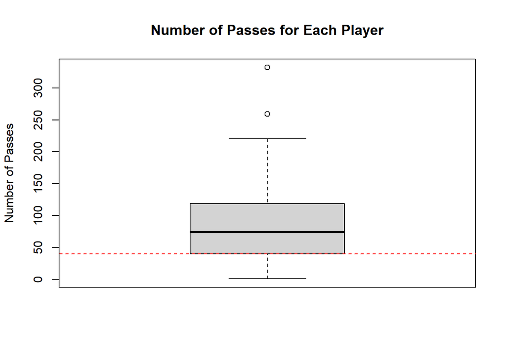

```r
# draw a boxplot for the number of passes for each player
boxplot(pass_sum,
        ylab = "Number of Passes",
        main = "Number of Passes for Each Player")
abline(h = quantile(pass_sum, 0.25), col="red", lty=2)
```

```r
quantile(pass_sum, c(0.25, 0.75))
```

```
##    25%    75%
##  40.00 118.75
```

```r
# remove players with less than 40 passes
Player_pass_list <- Player_pass_list %>%
  filter(pass_sum > 40)
```

```r
# calculate the successful pass rate
Player_pass_list$pass_successful_rate <- Player_pass_list$successful_pass_sum/Player_pass_list$pass_sum
Final_result_pass <- Player_pass_list[order(Player_pass_list$pass_successful_rate,decreasing = TRUE),]



Takeaway_January23 <- filter(NWHL,Event == "Takeaway",game_date == "2021-01-23")

Takeaway_January24 <- filter(NWHL,Event == "Takeaway",game_date == "2021-01-24")

Takeaway_January26 <- filter(NWHL,Event == "Takeaway",game_date == "2021-01-26")

Takeaway_January27 <- filter(NWHL,Event == "Takeaway",game_date == "2021-01-27")

Takeaway_January30 <- filter(NWHL,Event == "Takeaway",game_date == "2021-01-30")

Takeaway_January31 <- filter(NWHL,Event == "Takeaway",game_date == "2021-01-31")

Takeaway_February01 <- filter(NWHL,Event == "Takeaway",game_date == "2021-02-01")
```

```r
January23 = Takeaway_January23 %>% group_by(Player)  %>%
                    summarise(total_takeaway_Jan23 = length(Event))

January24 = Takeaway_January24 %>% group_by(Player)  %>%
                    summarise(total_takeaway_Jan24 = length(Event))

January26 = Takeaway_January26 %>% group_by(Player)  %>%
                    summarise(total_takeaway_Jan26 = length(Event))

January27 = Takeaway_January27 %>% group_by(Player)  %>%
                    summarise(total_takeaway_Jan27 = length(Event))

January30 = Takeaway_January30 %>% group_by(Player)  %>%
                    summarise(total_takeaway_Jan30 = length(Event))

January31 = Takeaway_January31 %>% group_by(Player)  %>%
                    summarise(total_takeaway_Jan31 = length(Event))

February01 = Takeaway_February01 %>% group_by(Player)  %>%
                    summarise(total_takeaway_Feb01 = length(Event))
```

```r
Player_merge1 <- merge(January23,January24,by="Player",all = TRUE)
Player_merge2 <- merge(Player_merge1,January26,by="Player",all = TRUE)
Player_merge3 <- merge(Player_merge2,January27,by="Player",all=TRUE)
Player_merge4 <- merge(Player_merge3,January30,by="Player",all=TRUE)
Player_merge5 <- merge(Player_merge4,January31,by="Player",all=TRUE)
Player_merge_final <- merge(Player_merge5,February01,by="Player",all=TRUE)
Player_merge_final
```

```
## [1] Player               total_takeaway_Jan23 total_takeaway_Jan24
## [4] total_takeaway_Jan26 total_takeaway_Jan27 total_takeaway_Jan30
## [7] total_takeaway_Jan31 total_takeaway_Feb01
## <0 rows> (or 0-length row.names)
```

```r
takeaway_sum = rowSums(Player_merge_final[2:8],na.rm = TRUE)
Total_game <- 7
Game_played <- Total_game - rowSums(is.na(Player_merge_final))
Player_takeaway_list <- cbind(Player_merge_final,takeaway_sum,Game_played)
```

```r
Player_takeaway_list$takeaway_per_game <- takeaway_sum/Game_played
Final_result_takeaway <- Player_takeaway_list[order(Player_takeaway_list$takeaway_per_game,decreasing = TRUE),]

Final_result_takeaway
```

```
##  [1] Player               total_takeaway_Jan23 total_takeaway_Jan24
##  [4] total_takeaway_Jan26 total_takeaway_Jan27 total_takeaway_Jan30
##  [7] total_takeaway_Jan31 total_takeaway_Feb01 takeaway_sum
## [10] Game_played          takeaway_per_game
## <0 rows> (or 0-length row.names)
```

```r
Play_January23 <- filter(NWHL,Event == "Play" | Event == "Incomplete Play",game_date == "2021-01-23")

Play_January24 <- filter(NWHL,Event == "Play" | Event == "Incomplete Play",game_date == "2021-01-24")

Play_January26 <- filter(NWHL,Event == "Play" | Event == "Incomplete Play",game_date == "2021-01-26")

Play_January27 <- filter(NWHL,Event == "Play" | Event == "Incomplete Play",game_date == "2021-01-27")

Play_January30 <- filter(NWHL,Event == "Play" | Event == "Incomplete Play",game_date == "2021-01-30")

Play_January31 <- filter(NWHL,Event == "Play" | Event == "Incomplete Play",game_date == "2021-01-31")

Play_February01 <- filter(NWHL,Event == "Play" | Event == "Incomplete Play",game_date == "2021-02-01")


successful_Play_January23 <- filter(NWHL,Event == "Play",game_date == "2021-01-23")

successful_Play_January24 <- filter(NWHL,Event == "Play",game_date == "2021-01-24")

successful_Play_January26 <- filter(NWHL,Event == "Play",game_date == "2021-01-26")

successful_Play_January27 <- filter(NWHL,Event == "Play",game_date == "2021-01-27")

successful_Play_January30 <- filter(NWHL,Event == "Play",game_date == "2021-01-30")

successful_Play_January31 <- filter(NWHL,Event == "Play",game_date == "2021-01-31")

successful_Play_February01 <- filter(NWHL,Event == "Play",game_date == "2021-02-01")
```

```r
January23_pass = Play_January23 %>% group_by(Player)  %>%
                    summarise(total_pass_Jan23 = length(Event))

January24_pass = Play_January24 %>% group_by(Player)  %>%
                    summarise(total_pass_Jan24 = length(Event))

January26_pass = Play_January26 %>% group_by(Player)  %>%
                    summarise(total_pass_Jan26 = length(Event))

January27_pass = Play_January27 %>% group_by(Player)  %>%
                    summarise(total_pass_Jan27 = length(Event))

January30_pass = Play_January30 %>% group_by(Player)  %>%
                    summarise(total_pass_Jan30 = length(Event))

January31_pass = Play_January31 %>% group_by(Player)  %>%
                    summarise(total_pass_Jan31 = length(Event))

February01_pass = Play_February01 %>% group_by(Player)  %>%
                    summarise(total_pass_Feb01 = length(Event))


successful_January23_pass = successful_Play_January23 %>% group_by(Player)  %>%
                    summarise(total_pass_Jan23_successful = length(Event))

successful_January24_pass = successful_Play_January24 %>% group_by(Player)  %>%
                    summarise(total_pass_Jan24_successful = length(Event))

successful_January26_pass = successful_Play_January26 %>% group_by(Player)  %>%
                    summarise(total_pass_Jan26_successful = length(Event))

successful_January27_pass = successful_Play_January27 %>% group_by(Player)  %>%
                    summarise(total_pass_Jan27_successful = length(Event))

successful_January30_pass = successful_Play_January30 %>% group_by(Player)  %>%
                    summarise(total_pass_Jan30_successful = length(Event))

successful_January31_pass = successful_Play_January31 %>% group_by(Player)  %>%
                    summarise(total_pass_Jan31_successful = length(Event))

successful_February01_pass = successful_Play_February01 %>% group_by(Player)  %>%
                    summarise(total_pass_Feb01_successful = length(Event))
```

```r
Player_merge1_play <- merge(January23_pass,January24_pass,by="Player",all = TRUE)
Player_merge2_play <- merge(Player_merge1_play,January26_pass,by="Player",all = TRUE)
Player_merge3_play <- merge(Player_merge2_play,January27_pass,by="Player",all=TRUE)
Player_merge4_play <- merge(Player_merge3_play,January30_pass,by="Player",all=TRUE)
Player_merge5_play <- merge(Player_merge4_play,January31_pass,by="Player",all=TRUE)
Player_merge6_play <- merge(Player_merge5_play,February01_pass,by="Player",all=TRUE)


Player_merge1_play_successful <- merge(successful_January23_pass,successful_January24_pass,by="Player",all = TRUE)
Player_merge2_play_successful <- merge(Player_merge1_play_successful,successful_January26_pass,by="Player",all = TRUE)
Player_merge3_play_successful <- merge(Player_merge2_play_successful,successful_January27_pass,by="Player",all=TRUE)
Player_merge4_play_successful <- merge(Player_merge3_play_successful,successful_January30_pass,by="Player",all=TRUE)
Player_merge5_play_successful <- merge(Player_merge4_play_successful,successful_January31_pass,by="Player",all=TRUE)
Player_merge6_play_successful <- merge(Player_merge5_play_successful,successful_February01_pass,by="Player",all=TRUE)



Player_pass_merge_final <- merge(Player_merge6_play,Player_merge6_play_successful,by = "Player",all=TRUE)
```

```r
pass_sum = rowSums(Player_pass_merge_final[2:8],na.rm = TRUE)
successful_pass_sum = rowSums(Player_pass_merge_final[9:15],na.rm = TRUE)
Player_pass_list <- cbind(Player_pass_merge_final,pass_sum,successful_pass_sum)
```

```r
Player_pass_list$pass_successful_rate <- successful_pass_sum/pass_sum
Final_result_pass <- Player_pass_list[order(Player_pass_list$pass_successful_rate,decreasing = TRUE),]

Final_result_pass
```

```
##  [1] Player                      total_pass_Jan23
##  [3] total_pass_Jan24            total_pass_Jan26
##  [5] total_pass_Jan27            total_pass_Jan30
##  [7] total_pass_Jan31            total_pass_Feb01
##  [9] total_pass_Jan23_successful total_pass_Jan24_successful
## [11] total_pass_Jan26_successful total_pass_Jan27_successful
## [13] total_pass_Jan30_successful total_pass_Jan31_successful
## [15] total_pass_Feb01_successful pass_sum
## [17] successful_pass_sum         pass_successful_rate
## <0 rows> (or 0-length row.names)
```

```r
puckrecovery_January23 <- filter(NWHL,Event == "Puck Recovery",game_date == "2021-01-23")

puckrecovery_January24 <- filter(NWHL,Event == "Puck Recovery",game_date == "2021-01-24")

puckrecovery_January26 <- filter(NWHL,Event == "Puck Recovery",game_date == "2021-01-26")

puckrecovery_January27 <- filter(NWHL,Event == "Puck Recovery",game_date == "2021-01-27")

puckrecovery_January30 <- filter(NWHL,Event == "Puck Recovery",game_date == "2021-01-30")

puckrecovery_January31 <- filter(NWHL,Event == "Puck Recovery",game_date == "2021-01-31")

puckrecovery_February01 <- filter(NWHL,Event == "Puck Recovery",game_date == "2021-02-01")
```

```r
January23_puckrecovery = puckrecovery_January23 %>% group_by(Player)  %>%
                    summarise(total_pukerecovery_January23 = length(Event))

January24_puckrecovery = puckrecovery_January24 %>% group_by(Player)  %>%
                    summarise(total_pukerecovery_January23 = length(Event))

January26_puckrecovery = puckrecovery_January26 %>% group_by(Player)  %>%
                    summarise(total_pukerecovery_January23 = length(Event))

January27_puckrecovery = puckrecovery_January27 %>% group_by(Player)  %>%
                    summarise(total_pukerecovery_January23 = length(Event))

January30_puckrecovery = puckrecovery_January30 %>% group_by(Player)  %>%
                    summarise(total_pukerecovery_January23 = length(Event))

January31_puckrecovery = puckrecovery_January31 %>% group_by(Player)  %>%
                    summarise(total_pukerecovery_January23 = length(Event))

February01_puckrecovery = puckrecovery_February01 %>% group_by(Player)  %>%
                    summarise(total_pukerecovery_January23 = length(Event))
```

```r
Player_merge1_puckrecovery <- merge(January23_puckrecovery,January24_puckrecovery,by="Player",all = TRUE)
Player_merge2_puckrecovery <- merge(Player_merge1_puckrecovery,January26_puckrecovery,by="Player",all = TRUE)
Player_merge3_puckrecovery <- merge(Player_merge2_puckrecovery,January27_puckrecovery,by="Player",all=TRUE)
Player_merge4_puckrecovery <- merge(Player_merge3_puckrecovery,January30_puckrecovery,by="Player",all=TRUE)
Player_merge5_puckrecovery <- merge(Player_merge4_puckrecovery,January31_puckrecovery,by="Player",all=TRUE)
Player_merge_final_puckrecovery <- merge(Player_merge5_puckrecovery,February01_puckrecovery,by="Player",all=TRUE)
Player_merge_final_puckrecovery
```

```
## [1] Player                         total_pukerecovery_January23.x
## [3] total_pukerecovery_January23.y total_pukerecovery_January23.x
## [5] total_pukerecovery_January23.y total_pukerecovery_January23.x
## [7] total_pukerecovery_January23.y total_pukerecovery_January23
## <0 rows> (or 0-length row.names)
```

```r
puckrecovery_sum = rowSums(Player_merge_final_puckrecovery[2:8],na.rm = TRUE)
Total_game_puckrecovery <- 7
Game_played_puckrecovery <- Total_game - rowSums(is.na(Player_merge_final_puckrecovery))
Player_puckrecovery_list <- cbind(Player_merge_final_puckrecovery,puckrecovery_sum,Game_played_puckrecovery)
```

```r
Player_puckrecovery_list$puckrecovery_per_game <- puckrecovery_sum/Game_played_puckrecovery
Final_result_puckrecovery <- Player_puckrecovery_list[order(Player_puckrecovery_list$puckrecovery_per_game,decreasing = TRUE),]

Final_result_puckrecovery
```

```
##  [1] Player                         total_pukerecovery_January23.x
##  [3] total_pukerecovery_January23.y total_pukerecovery_January23.x
##  [5] total_pukerecovery_January23.y total_pukerecovery_January23.x
##  [7] total_pukerecovery_January23.y total_pukerecovery_January23
##  [9] puckrecovery_sum               Game_played_puckrecovery
## [11] puckrecovery_per_game
## <0 rows> (or 0-length row.names)
```

```r
Final_merge1 <- merge(Final_result_pass,Final_result_takeaway,by="Player",all = TRUE)
Final_merge <- merge(Final_merge1,Final_result_puckrecovery,by="Player",all = TRUE)
Result_filter<- Final_merge[,c('Player','pass_sum','successful_pass_sum','pass_successful_rate','takeaway_sum','Game_played','takeaway_per_game','puckrecovery_sum','puckrecovery_per_game')]
median_takeaway_sum <- mean(Result_filter$takeaway_sum,na.rm = TRUE)
average_player <- filter(Result_filter,takeaway_sum>median_takeaway_sum)
```